# E-news Express Project

```python
#Libraries to help with reading data and manipulating data
import numpy as np
import pandas as pd
import matplotlib.pyplot as plt

# Libraries that support data visualization
import matplotlib.pyplot as plt
%matplotlib inline
import seaborn as sns

# Libraries to suppress warnings
import warnings
warnings.filterwarnings("ignore")

#this library contains a large number of probability distributions as well as a growing library of statistical functions.
import scipy.stats as stats
```

```python
data = pd.read_csv("abtest.csv", index_col = 0)
```

```python
#copying data to another variable to avoid any changes to original data
df = data.copy()
```

```python
#Looking at first 5 observations
df.head()
```

| user_id | group | landing_page | time_spent_on_the_page | converted | language_preferred |
| --- | --- | --- | --- | --- | --- |
| 546592 | control | old | 3.48 | no | Spanish |
| 546468 | treatment | new | 7.13 | yes | English |
| 546462 | treatment | new | 4.40 | no | Spanish |
| 546567 | control | old | 3.02 | no | French |
| 546459 | treatment | new | 4.75 | yes | Spanish |

#### Observations

1. group contains - control and treatment (2 user groups)
2. landing_pages - old and new
3. time_spent_on_the_page is the only numerical variable.
4. converted column containes yes or no values
5. Languages preferred are Spanish, English, French.

```python
#checking the shape of the data
df.shape
```

```
(100, 5)
```

```python
#Inspect the dataset
df.info()
```

```
<class 'pandas.core.frame.DataFrame'>
Int64Index: 100 entries, 546592 to 546483
Data columns (total 5 columns):
 #   Column                  Non-Null Count  Dtype
---  ------                  --------------  -----
 0   group                   100 non-null    object
 1   landing_page            100 non-null    object
 2   time_spent_on_the_page  100 non-null    float64
 3   converted               100 non-null    object
 4   language_preferred      100 non-null    object
dtypes: float64(1), object(4)
memory usage: 4.7+ KB
```

#### Observations

1. There are 100 observations.
2. There are a numeric feautures(time_spent_on_the_page).
3. group, landing_page, converted, language_preferred are object datatype(should be converted to categorical variables)

```python
#checking for the missing values
df.isnull().sum()
```

```
group                     0
landing_page              0
time_spent_on_the_page    0
converted                 0
language_preferred        0
dtype: int64
```

There are no missing values in the data

## Summary of the data

```python
df.describe().T
```

|  | count | mean | std | min | 25% | 50% | 75% | max |
| --- | --- | --- | --- | --- | --- | --- | --- | --- |
| time_spent_on_the_page | 100.0 | 5.3778 | 2.378166 | 0.19 | 3.88 | 5.415 | 7.0225 | 10.71 |

#### Observations

1. The time spent on the page vary a lot with minimum time 0.19 minutes to 10.71 minutes.
2. There is a huge differrence between mean and maximum value.

```python
# By default, describe() function shows only the summary of numeric value. Lets check the summary of non-numeric variables
df.describe(exclude='number').T
```

|  | count | unique | top | freq |
| --- | --- | --- | --- | --- |
| group | 100 | 2 | treatment | 50 |
| landing_page | 100 | 2 | new | 50 |
| converted | 100 | 2 | yes | 54 |
| language_preferred | 100 | 3 | French | 34 |

```python
# Lets check the count of each unique category in each of the categorical variables.
categorycols = ['group', 'landing_page', 'converted', 'language_preferred']

for column in categorycols:
    print(df[column].value_counts())
    print('_'*40)
```

```
treatment    50
control      50
Name: group, dtype: int64
________________________________________
new    50
old    50
Name: landing_page, dtype: int64
________________________________________
yes    54
no     46
Name: converted, dtype: int64
________________________________________
French     34
Spanish    34
English    32
Name: language_preferred, dtype: int64
________________________________________
```

```python
for column in categorycols:
    df[column] = df[column].astype("category")
```

1. Out of 100 users, 50 belong to the first group(control) and the rest belong to the second group(treatment).
2. Out of 100 users, landing page of 50 users is 'new' while the landing page of the rest is 'old'.
3. 54 Users converted to subcriber of the news portal
4. Out of 100, 34 users prefer Spanish, the other 34 users prefer French while the rest of the 32 users prefer English.

### Check for unique values in the column

```python
print(df.group.unique())
```

```
['control', 'treatment']
Categories (2, object): ['control', 'treatment']
```

```python
print(df.landing_page.unique())
```

```
['old', 'new']
Categories (2, object): ['old', 'new']
```

```python
print(df.converted.unique())
```

```
['no', 'yes']
Categories (2, object): ['no', 'yes']
```

```python
print(df.language_preferred.unique())
```

```
['Spanish', 'English', 'French']
Categories (3, object): ['Spanish', 'English', 'French']
```

### Exploratory Data Analysis

### Let us explore Numerical Value first

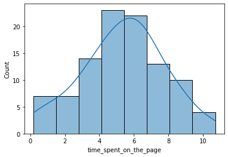

```python
sns.histplot(df.time_spent_on_the_page, kde = True)
```

1. Most of the users use the page between 4 -6.5 minutes.
2. Mean time_spent_on_the_page is 5.4 minutes and the median is 5.4 minutes.

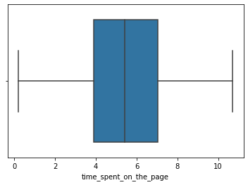

```python
sns.boxplot(df.time_spent_on_the_page,orient = "h");
```

#### Observations

1. time_spent_on_the page doesnot have any outliers.

### Lets explore the Categorical Variables

#### Observation on Group

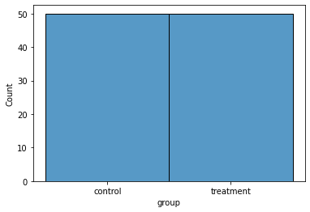

```python
sns.histplot(df.group);
```

#### Observations

1. 50% of the customers belong to the group control and the rest belong to the group treatment.

#### Observation on landing_page

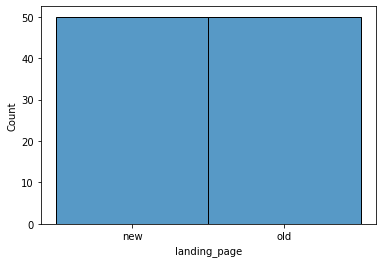

```python
sns.histplot(df.landing_page);
```

#### Observations

1. The landing_page of 50% of the users is old and the rest is new.

#### Observations on converted

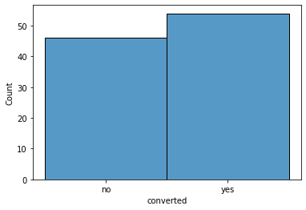

```python
sns.histplot(df.converted);
```

#### Observations

1. Out of 100, 54% percent of the users have subscribed.

#### Observations on language_preferred

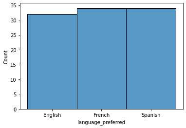

```python
sns.histplot(df.language_preferred);
```

#### Observations

1. Most of the user either prefer Spanish or French.

## Bivariate Analysis

### Plotting the Bivariate Analysis to understand the interaction with each other

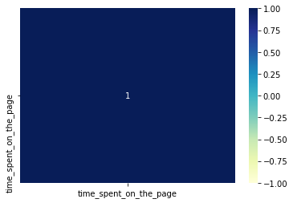

```python
sns.heatmap(df.corr(),cmap="YlGnBu",vmin=-1,vmax=1, annot=True)
```

#### Observation

1. There is only one numerical featire. Hence the value is 1.

### Bivariate Scatter Plots

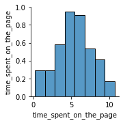

```python
sns.pairplot(df);
```

##### Observation

Since, there is only numerical variable. Only one histogram.

### Check group count by converted

```python
pd.crosstab(df.group,df.converted)
```

| converted group | no | yes |
| --- | --- | --- |
| control | 29 | 21 |
| treatment | 17 | 33 |

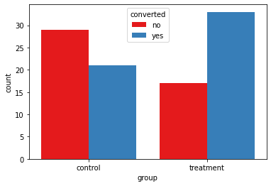

```python
sns.countplot(x="group", hue="converted", data=df, palette='Set1',saturation=50 );
```

#### Observations

1. There are more users from treatment group who converted to subscriber of the news portal.
2. There are more user from control group who did not convert to a subscriber.

### Check group count by language_preferred.

```python
pd.crosstab(df.group,df.language_preferred)
```

| language_preferred group | English | French | Spanish |
| --- | --- | --- | --- |
| control | 16 | 17 | 17 |
| treatment | 16 | 17 | 17 |

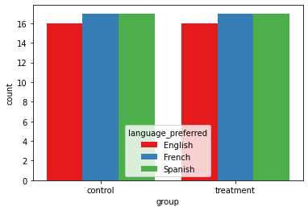

```python
sns.countplot(x="group", hue="language_preferred", data=df, palette='Set1',saturation=50 );
```

#### Observations

1. Number of users who choose French, Spanish and English are same among both the groups - control and treatment.

### Check converted count by language_preferred

```python
pd.crosstab(df.converted,df.language_preferred)
```

| language_preferred converted | English | French | Spanish |
| --- | --- | --- | --- |
| no | 11 | 19 | 16 |
| yes | 21 | 15 | 18 |

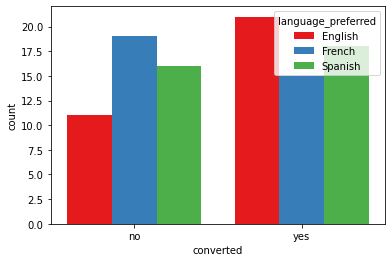

```python
sns.countplot(x="converted", hue="language_preferred", data=df, palette='Set1',saturation=50 );
```

#### Observations

1. The users who converted to subscriber mostly preferred English.
2. The users who didnot convert to subscriber mostly preferred French language.

### Check converted count by landing_page

```python
    pd.crosstab(df.converted,df.landing_page)
```

| landing_page converted | new | old |
| --- | --- | --- |
| no | 17 | 29 |
| yes | 33 | 21 |

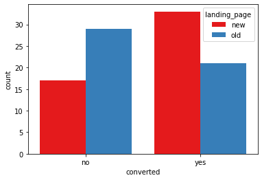

```python
sns.countplot(x="converted", hue="landing_page", data=df, palette='Set1',saturation=50 );
```

#### Observation

1. The users who converted to subscriber mostly preferred new_landing_page.
2. The users who didnot convert to subscriber preferred old_landing_page.

### Check group count by landing_page

```python
pd.crosstab(df.group,df.landing_page)
```

| landing_page group | new | old |
| --- | --- | --- |
| control | 0 | 50 |
| treatment | 50 | 0 |

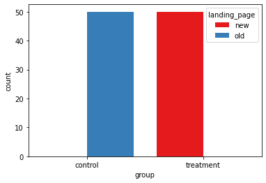

```python
sns.countplot(x="group", hue="landing_page", data=df, palette='Set1',saturation=50 );
```

#### Observations

1. Control group preferred old_landing_page.
2. treatment group preferred new_landing_page.

### Time_spent_on_the page Vs group

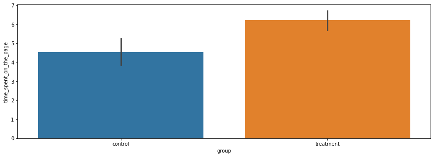

```python
plt.figure(figsize=(15,5))

ax = sns.barplot(x='group', y='time_spent_on_the_page', data=data)
```

#### Observations

1. The mean time spent on the page by treatment group users is greater than control group users.

### Time_spent_on_the_page Vs landing_page

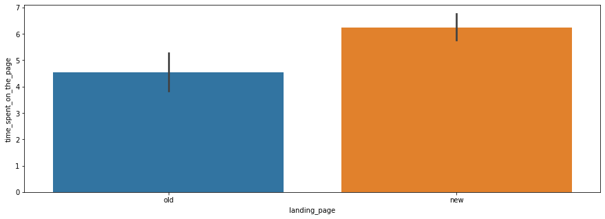

```python
plt.figure(figsize=(15,5))

ax = sns.barplot(x='landing_page', y='time_spent_on_the_page', data=data)
```

#### Observations

1. The mean time spent on the new page is greater than the mean time spent on the old page.

### Time_spent_on_the_page Vs converted

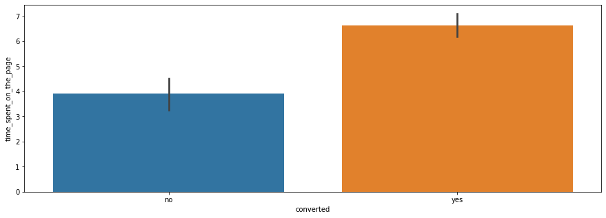

```python
plt.figure(figsize=(15,5))

ax = sns.barplot(x='converted', y='time_spent_on_the_page', data=data)
```

#### Observations

1. The user who has subscribed for the news portal spends more time than the user who didnot subscribe.

### Time_spent_on_the_page Vs language_preferred

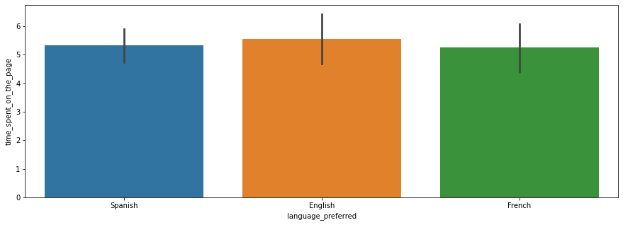

```python
plt.figure(figsize=(15,5))

ax = sns.barplot(x='language_preferred', y='time_spent_on_the_page', data=data)
```

#### Observations

1. The users who prefer English slightly spend more time than the users who prefer Spanish or French.

### Correlation between time_spent_on_the_page, group and language_preferred

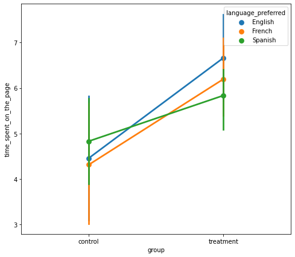

```python
figure = plt.figure(figsize=(8,7))
sns.pointplot(x="group", y="time_spent_on_the_page", data=df, hue='language_preferred', palette='tab10' )
plt.show()
```

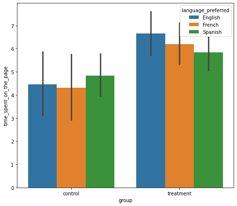

```python
figure = plt.figure(figsize=(8,7))
sns.barplot(x="group", y="time_spent_on_the_page", data=df, hue='language_preferred', palette='tab10' )
plt.show()
```

### Correlation between time_spent_on_the_page, group and landing_page

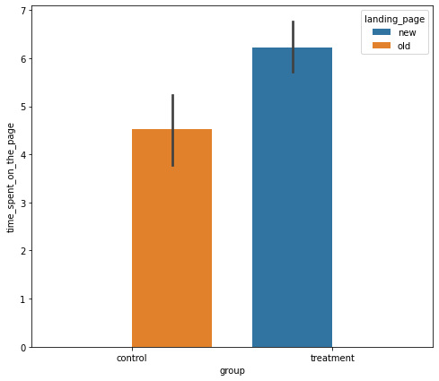

```python
figure = plt.figure(figsize=(8,7))
sns.barplot(x="group", y="time_spent_on_the_page", data=df, hue='landing_page', palette='tab10' )
plt.show()
```

#### Observations

1. Treatment group spends more time on the page than control group as all the treatment group users prefer new landing page.

### Correlation between time_spent_on_the_page, converted and group

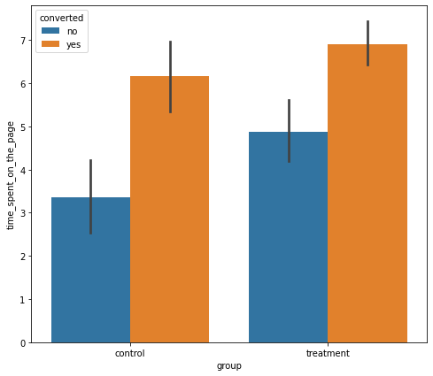

```python
figure = plt.figure(figsize=(8,7))
sns.barplot(x="group", y="time_spent_on_the_page", data=df, hue='converted', palette='tab10' )
plt.show()
```

#### Observations

1. Among both control and treatment users, time spent on the page is more among the users who have subscribed.

### Correlation between time_spent_on_the_page, converted and landing_page

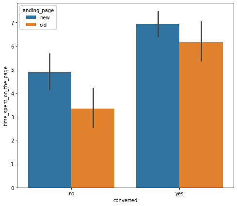

```python
figure = plt.figure(figsize=(8,7))
sns.barplot(x="converted", y="time_spent_on_the_page", data=df, hue='landing_page', palette='tab10' )
plt.show()
```

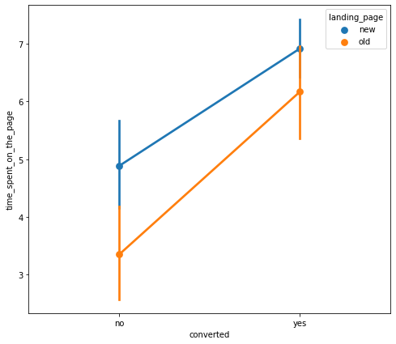

```python
figure = plt.figure(figsize=(8,7))
sns.pointplot(x="converted", y="time_spent_on_the_page", data=df, hue='landing_page', palette='tab10' )
plt.show()
```

##### Observations

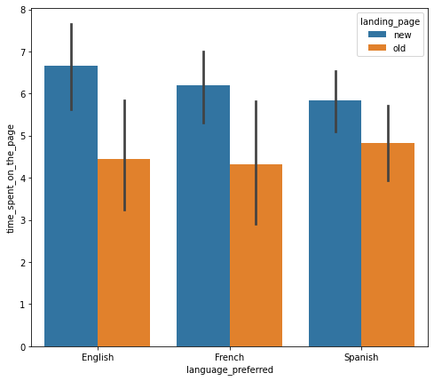

```python
figure = plt.figure(figsize=(8,7))
sns.barplot(x="language_preferred", y="time_spent_on_the_page", data=df, hue='landing_page', palette='tab10' )
plt.show()
```

#### Observation

1. time_spent_on_new_landing_page is more irrespective of the language preferred

### Correlation between time_spent_on_the_page, converted and language_preferred

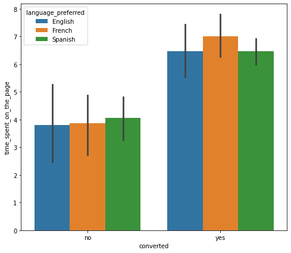

```python
figure = plt.figure(figsize=(8,7))
sns.barplot(x="converted", y="time_spent_on_the_page", data=df, hue='language_preferred', palette='tab10' )
plt.show()
```

#### Observations

1. Subscribers spend more time than non-subscribers.
2. Among subscribers, users who prefer French spend more.
3. Among non - subscribers, users who prefer Spanish spend more time.
4. Among subscribers, users who prefer English and Spanish spend equal amont of time as there is only slight difference.

### Correlation between time_spent_on_the_page, converted and language_preferred

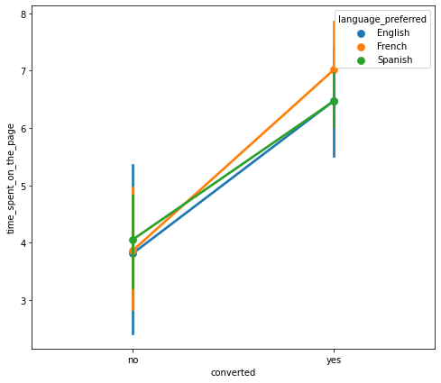

```python
figure = plt.figure(figsize=(8,7))
sns.pointplot(x="converted", y="time_spent_on_the_page", data=df, hue='language_preferred', palette='tab10' )
plt.show()
```

### group Vs time_spent_on_the_page

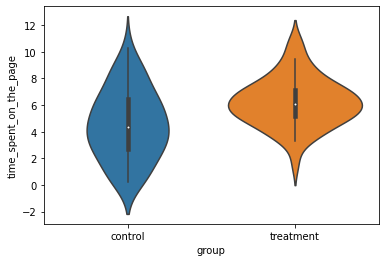

```python
 ax = sns.violinplot(x =df.group, y = df['time_spent_on_the_page'])
```

### language_preferred vs time_spent_on_the_page

#### Observation

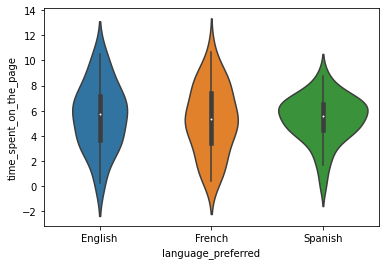

```python
 ax = sns.violinplot(x =df.language_preferred, y = df['time_spent_on_the_page'])
```

#### Observations

```python
from pandas_profiling import ProfileReport
# Use the original dataframe, so that original features are considered
prof_df = ProfileReport(df)
# to view report created by pandas profile
prof_df
```

[interactive chart not shown]

## HYPOTHESIS TESTS

### 2. Do the users spend more time on new landing page than the old landing page.

#### Visual Analysis

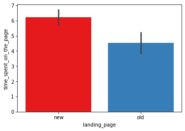

```python
sns.barplot(x="landing_page", y="time_spent_on_the_page", data=df, palette='Set1',saturation=50);
```

#### Observation

This is a two-sample problem where new landing page and old landing page populations are independent. Further, this is one-tailed hypothesis problem, concerning populations means $\mu_1 and \mu_2$, the mean time spent on new landing and old landing pages.

We will test the null hypothesis

> $H_0:\mu_1=\mu_2$

against the alternate hypothesis

> $H_a:\mu_1>\mu_2$

```python
print(df.groupby('landing_page')['time_spent_on_the_page'].mean())
```

```
landing_page
new    6.2232
old    4.5324
Name: time_spent_on_the_page, dtype: float64
```

```python
print(df.groupby('landing_page')['time_spent_on_the_page'].std())
```

```
landing_page
new    1.817031
old    2.581975
Name: time_spent_on_the_page, dtype: float64
```

#### Significance of the test

Test for the equality of two population means

> $H_0:\mu_1=\mu_2$

#### Assumptions

1. Continuuous data - time_spent_on_the_page
2. Normally distributed population or sample size > 30
3. Independent populations
4. Known population standard deviations $\sigma_1$ and $\sigma_2$
5. Random Sampling from the population

#### Test Statistic Distribution

Standard Normal Distribution

#### Two independent sample z-test

#### Let's write the null and alternative hypothesis

Let $\mu_1, \mu_2$ be the mean time spent on new landing and old landing page respectively.

We will test the null hypothesis

> $H_0:\mu_1=\mu_2$

against the alternate hypothesis

> $H_a:\mu_1>\mu_2$

#### Lets find the p_value

```python
from numpy import sqrt, abs
from scipy.stats import norm
X1 = 6.22 # mean time spent on new landing page
X2 = 4.53 # mean time spent on old landing page
sd1 = 1.82 #standard deviation of time spent on new landing page
sd2 = 2.58 #standard deviation of time spent on old landing page
n1 = 50 # size of sample 1
n2 = 50 # size of sample 2
se = sqrt(sd1**2/n1+sd2**2/n2) # standard error
test_stat = ((X1- X2) - 0)/se  #test statistic
p_value = 1- norm.cdf(abs(test_stat)) # calculating one-tailed p-value
p_value
```

```
7.68963654407262e-05
```

#### Insight

As the p_value is much less than the level of significance 0.05. We reject the null hypothesis. Thus, from the statistical evidence we can say that time spent on new landing page is more than time spent on old landing page.

### 3. Is the conversion rate for the new page greater than the conversion rate for the old page.

#### Visual Analysis

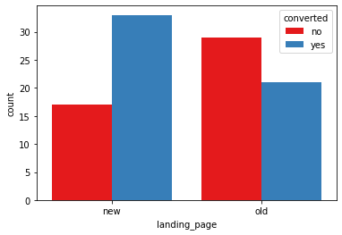

```python
sns.countplot(x="landing_page", hue="converted", data=df, palette='Set1',saturation=50);
```

#### Observation

1. Among the users who prefer new landing page, there are more users who converted to subscriber.
2. Among the users who prefer old landing page, there are less subscribers.

```python
pd.crosstab(df.converted,df.landing_page)
```

| landing_page converted | new | old |
| --- | --- | --- |
| no | 17 | 29 |
| yes | 33 | 21 |

#### Significance of the test:

1. Test for the equality of proportions

#### Assumptions:

1. Binomially distributed and Independent populations
2. Random sampling from the populations.
3. When both mea(np) and n(1-p) are greater than or equal to 10, binomial distribution can be approximated by a normal distribution

#### Test Statistic Distribution

### Let's write the null and alternative hypothesis

Let $p_1,p_2$ be the conversion rates of new landing and old landing pages

The manufacturer will test the null hypothesis

> $H_0:p_1 =p_2$

against the alternate hypothesis

> $H_a:p_1 > p_2$

> $np_1 = 50\cdot \frac{33}{50} =33 \geq 10\\ n(1-p_1) = 50 \cdot \frac{50-33}{50} =17 \geq 10 \\ np_2 = 50\cdot \frac{21}{50} =21 \geq 10\\ n(1-p_2) = 50 \cdot \frac{50-21}{50} =29 \geq 10 $

```python
### Lets find the p_value
from statsmodels.stats.proportion import proportions_ztest

# setting the counts of the conversion rate of both the pages
conversion_rate = np.array([33,21])

#setting the sample sizes
nobs = np.array([50,50])

#p_value

test_stat, p_value = proportions_ztest(conversion_rate,nobs)
p_value
```

```
0.016052616408112556
```

### Insight

As the p_value is less than the level of significance 0.05, we reject the null hypothesis. Thus,from the statistical analysis we can say conversion rate for the new page greater than the conversion rate for the old page.